# Corporacion Favorita Grocery Unit Sales Forecasting Part 1

Fannie Yuen

2017-12-11

# Introduction

Planning and forecasting is never easy for retailers. Demand forecasting can be influenced by various factors, for example sales promotions, competitions, holidays and events, seasonality, locations and weather.

In this challenge, I am going to predict the 2 weeks of daily quantity of items sold in each store with promotion information for Corporacion Favorita, a grocery retailer with about 50 stores in Ecuador. Reliable demand forecasts help retailers to effectively manage inventory to avoid stock-out, prevent massive level of stock that do not sell and maintain adequate inventory.

### Data Description

Provided historical unit sales data, the task is to predict the *unit sales* for the test set based on the [training and other data](https://www.kaggle.com/c/favorita-grocery-sales-forecasting/data).

### Evaluation

This challenge began on Oct 19, 2017 and will be finished on Jan 15, 2018. Submission will be evaluated on the [Normalized Weighted Root Mean Squared Logarithmic Error (NWRMSLE)](https://www.kaggle.com/c/favorita-grocery-sales-forecasting#evaluation).

More information can be found on the [Kaggle competition page](https://www.kaggle.com/c/favorita-grocery-sales-forecasting).

# Plan of the Project

This project starts with an exploratory data analysis on the available datasets. The aim of this initial step is to mine any underlying signals which may be useful in model building.

The related datasets will be combined to the train dataset by unique identifiers, and therefore with additional variables and features.

A key challenge of this task is to deal with a large amount of categorical variables with a huge number of unique values. These include the items and stores variables, as well as their additional metadata. A treatment utilizing Average Leaving-one-out Response Rate will transform the categorical variables into the expected response values. The transformation with meaning numerical values can be used for further analysis and model building.

The test set will not be used in this analysis, as we do not have the actual response value *unit_sales* to evaluate the prediction. Instead, a new dataset based on the train data and other data sets will be generated and divided into training and test sets for internal model evaluation.

# Data Preparation

The main R package is **tidyverse**, which contains **tidyr**, **dplyr** for data manipulation and ggplot for visualisation. **fread()** from **data.table** is used for fast file reading. The **describe()** function from **Hmisc** provides detailed summary statistics. **ymd()** from lubridate is used to format dates. **str_c()** from **stringr** is used for connecting character strings.

```r
library(data.table)
library(lubridate)
library(Hmisc)
library(tidyverse)
library(stringr)
```

### Exploratory Data Analysis (EDA)

##### train

The exploration begins with the train file followed by metadata and additional data files with summary statistics and visualisations. This exploration data analysis aims to provide insights in the dataset, which is crucial for the feature selection in model building.

```r
train <- fread('train.csv', showProgress = TRUE)
```

```r
train[, lapply(.SD, function(x) length(unique(x)))]
glimpse(train)
summary(train)
```

In the train data, there were 125,497,040 records with unique id 0 to 125,497,039 and an additional variable *unit_sales* as response variable. This dataset consists of 1,684 days, more than 4 years of data ranging from Jan 1, 2013 to Aug 15, 2017, 54 *stores* (out of hundreds in reality) with unique store id 1 to 54, and 4,036 *items* (out of over 200,000 different products). 3 *onpromotion* values are available, TRUE, FALSE & missing values. Negative values of unit sales refer to refund records. The variables can then be transformed into date and categorical format.

```r
train$Date <- ymd(train$date)
train$Date <- ymd(train$date)
train$Store_nbr <- as.factor(train$store_nbr)
train$Item_nbr <- as.factor(train$item_nbr)
train$Onpromotion <- as.factor(train$onpromotion)
```

*date* is an attractive variable which can be exploited for features generation. Since the dataset has a timeframe over 4 years, the components *Year*, *Quarter*, *Month*, *Yearday*, *Monthday* and *Weekday* can be extracted. Moreover, a *sales_refund* variable is used to identify the number of items sold or refunded based on the sign.

Let us explore the response variable *unit_sales*.

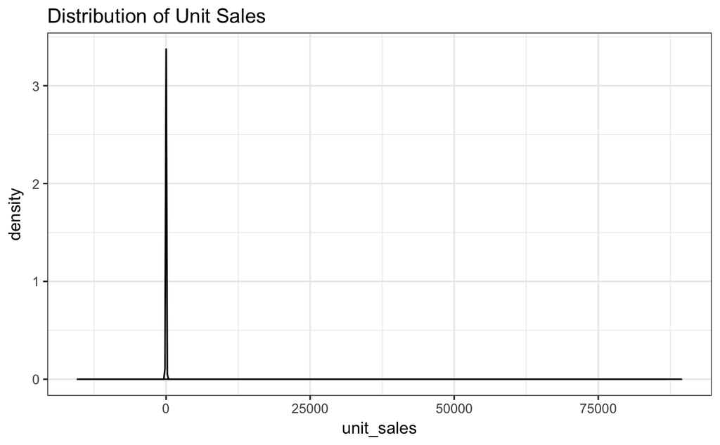

```r
train %>%
  ggplot(aes(unit_sales))+geom_density()+
  theme_bw()+
  labs(title="Distribution of Unit Sales")
```

```r
describe(train$unit_sales)
```

*unit_sales* exhibits a long tail distribution with extreme unit sales of 89,440 & unit refunds of 15,372. These extreme quantities may be caused by the slow-moving items with unpredictable demand. The following table shows the top 5 unit sales over 20,000 and top 5 refunds more than 3,600.

| id | date | store_nbr | item_nbr | unit_sales | onpromotion | Date | Store_nbr | Item_nbr | Onpromotion | sales_refund | Year | Quarter | Month | Yearday | Monthday | Weekday |
| --- | --- | --- | --- | --- | --- | --- | --- | --- | --- | --- | --- | --- | --- | --- | --- | --- |
| 93189596 | 2016-10-07 | 39 | 1976284 | 89440 | FALSE | 2016-10-07 | 39 | 1976284 | FALSE | sales | 2016 | 4 | Oct | 281 | 7 | Fri |
| 76939364 | 2016-04-21 | 20 | 841842 | 44142 | FALSE | 2016-04-21 | 20 | 841842 | FALSE | sales | 2016 | 2 | Apr | 112 | 21 | Thurs |
| 77960441 | 2016-05-02 | 2 | 1162932 | 30000 | FALSE | 2016-05-02 | 2 | 1162932 | FALSE | sales | 2016 | 2 | May | 123 | 2 | Mon |
| 76693277 | 2016-04-18 | 45 | 559870 | 20748 | FALSE | 2016-04-18 | 45 | 559870 | FALSE | sales | 2016 | 2 | Apr | 109 | 18 | Mon |
| 77959454 | 2016-05-02 | 2 | 305227 | 20000 | FALSE | 2016-05-02 | 2 | 305227 | FALSE | sales | 2016 | 2 | May | 123 | 2 | Mon |
| 79205524 | 2016-05-14 | 53 | 1229028 | -3600 | FALSE | 2016-05-14 | 53 | 1229028 | FALSE | refund | 2016 | 2 | May | 135 | 14 | Sat |
| 79204535 | 2016-05-14 | 53 | 323921 | -3606 | FALSE | 2016-05-14 | 53 | 323921 | FALSE | refund | 2016 | 2 | May | 135 | 14 | Sat |
| 79204331 | 2016-05-14 | 53 | 119026 | -4673 | FALSE | 2016-05-14 | 53 | 119026 | FALSE | refund | 2016 | 2 | May | 135 | 14 | Sat |
| 111606073 | 2017-04-06 | 32 | 1158720 | -10002 | FALSE | 2017-04-06 | 32 | 1158720 | FALSE | refund | 2017 | 2 | Apr | 96 | 6 | Thurs |
| 49592112 | 2015-06-22 | 18 | 1166474 | -15372 | FALSE | 2015-06-22 | 18 | 1166474 | FALSE | refund | 2015 | 2 | Jun | 173 | 22 | Mon |

Further investigation shows that these extreme sales and refund activities happened mostly in Apr and May 2016. Lots of refunds took place on May 14, 2016 from store 53. We might expect that the holiday event metadata will tell us more.

Next, we can investigate the quantitiy sold in the time dimension.

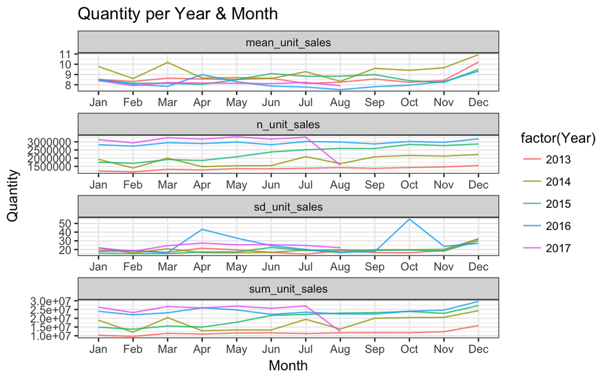

```r
train %>%
  group_by(Year, Month) %>%
  summarise(
    n_unit_sales=n(),
    mean_unit_sales=mean(unit_sales),
    sd_unit_sales=sd(unit_sales),
    sum_unit_sales=sum(unit_sales)) %>%
  gather(x, y, n_unit_sales:sum_unit_sales) %>%
  ggplot(aes(x=Month, y=y, color=factor(Year), group=factor(Year))) +
  geom_line(size = 0.5, alpha = 0.8) +
  facet_wrap(~ x, ncol = 1, scales = "free") +
  theme_bw() +
  labs(title = "Quantity per Year & Month",
       y = "Quantity")
```

By looking at the aggregated unit sales grouped by year and month, some points can be noted:

- While the number of records and sum of unit sales increased, mean of unit sales increased and then decreased over the years.
- Mean of unit sales was highest in general in 2014.
- As a current trend in retail, mean of unit sales in December is highest compared to other months.
- Mean of unit sales was higher in Jan and Mar 2014 than in other years.
- There were great variations in quantity sold in Apr 2016 and in Oct 2016 which should be further explored.

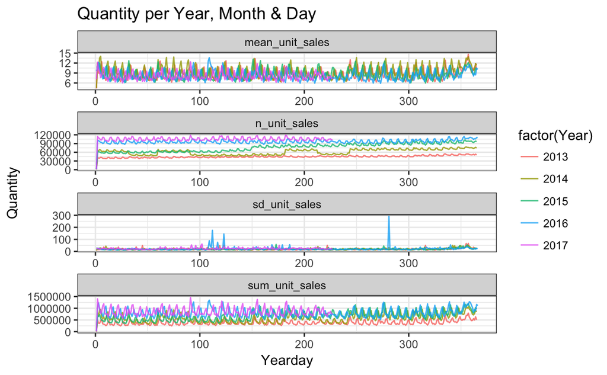

```r
train %>%
  group_by(Year, Yearday) %>%
  summarise(
    n_unit_sales=n(),
    mean_unit_sales=mean(unit_sales),
    sd_unit_sales=sd(unit_sales),
    sum_unit_sales=sum(unit_sales)) %>%
  gather(x, y, n_unit_sales:sum_unit_sales) %>%
  ggplot(aes(x=Yearday, y=y, color=factor(Year), group=factor(Year))) +
  geom_line(size = 0.5, alpha = 0.8) +
  facet_wrap(~ x, ncol = 1, scales = "free") +
  theme_bw() +
  labs(title = "Quantity per Year, Month & Day", y = "Quantity")
```

By taking a deeper look at the data from daily perspective, further remarks can be made:

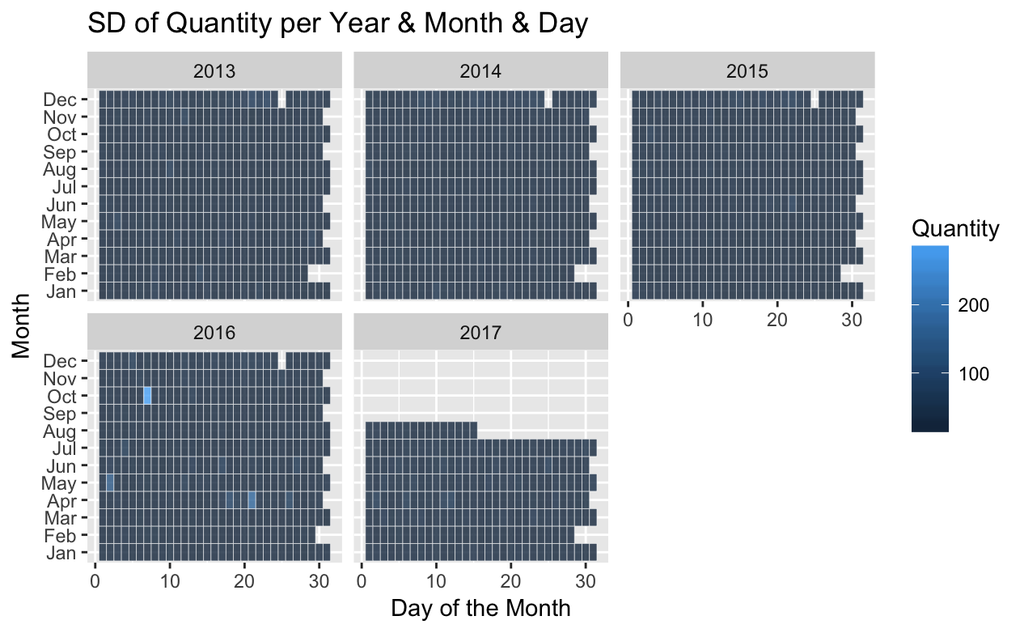

```r
train %>%
  group_by(Year, Month, Monthday) %>%
  summarise(sd_unit_sales=sd(unit_sales)) %>%
  ggplot(aes(x=Monthday, y=Month, fill=sd_unit_sales)) +
  facet_wrap(~Year) +
  geom_tile(alpha=0.8, color="white") +
  scale_colour_gradientn(colours = c("darkblue", "white"))+
  theme_gray() +
  theme(legend.position="right") +
  labs(title="SD of Quantity per Year & Month & Day", x="Day of the Month", y="Month",
fill="Quantity")
```

From the tile plot of standard deviation of *unit_sales*, sharp variations on Apr 21, May 2 & Oct 7, 2016 are identified. Moreover, the changing colours show some variation of quantity sold in 2016.

##### transaction

Now, let us take a look at the transaction data.

```r
tran <- fread('transactions.csv', showProgress = TRUE)
```

```r
tran[, lapply(.SD, function(x) length(unique(x)))]
glimpse(tran)
```

This data contains transaction figures of 1,682 days from Jan 1, 2013 to Aug 15, 2017 in 54 stores with 90,828 days and stores combinations. The actual number of 83,488 records indicates that not every store had a record in the given period.

```r
tran$Date <- ymd(tran$date)
tran$Date <- ymd(tran$date)
tran$Store_nbr <- as.factor(tran$store_nbr)
tran$date_store=str_c(tran$date, "//", as.character(tran$store_nbr))
```

A further transformation of the variables will be useful for interpretation. Moreover, since each transaction figure was generated by each day and each store, an addition string variable joining the date and store values is created as unique identifier of the transaction dataset, which will be used to join the train dataset.

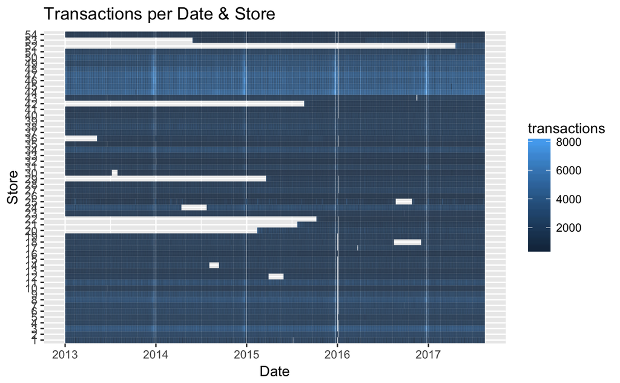

```r
ggplot(tran, aes(x=Date, y=Store_nbr))+
  geom_tile(aes(fill=transactions), alpha=0.8) +
  scale_colour_gradientn(colours = c("darkblue", "white"))+
  theme_gray() +
  theme(legend.position="right") +
  labs(title = "Transactions per Date & Store", y="Store")
```

Some points are noted:

- All stores were closed on Dec 25 and most stores were closed on Jan 1 and / or Jan 2.
- Not all stores were operating in the same period of time. Some stores started business later. Some stores were closed for a couple of days which might be due to renovation or relocation or replenishment.
- Some seasonalities can be revealed by the contrast of colours.
- Some stores had significantly more transactions than others, for instance store no. 3, 44-49.

##### store

Now, let us take a look at the store metadata.

```r
stores <- fread('stores.csv', showProgress = TRUE)
```

```r
stores[, lapply(.SD, function(x) length(unique(x)))]
glimpse(stores)
summary(stores)
```

There were 54 stores located in 22 cities, 16 states, 5 types & 17 clusters of similar stores. Let us transform them into categorical variables.

```r
stores$Store_nbr <- as.factor(stores$store_nbr)
stores$City <- as.factor(stores$city)
stores$State <- as.factor(stores$state)
stores$Type <- as.factor(stores$type)
stores$Cluster <- as.factor(stores$cluster)
```

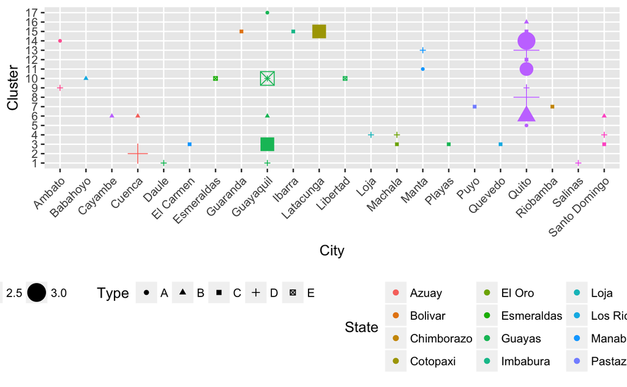

```r
ggplot(stores)+
  geom_count(aes(x=City, y=Cluster, shape=Type, color=State))+
  theme(axis.text.x = element_text(angle = 45, vjust = 1, hjust = 1), legend.position="bottom")
```

Most variation of stores could be found in the capital city Quito in Pichincia, followed by the most populous city Guayaquil in Guayas. The *cluster* or *type* of stores are useful in identifying quantity sold of unknown stores.

##### oil

Let us see the first time series of the oil price here.

```r
oil <- fread('oil.csv', showProgress = TRUE)
```

```r
oil[, lapply(.SD, function(x) length(unique(x)))]
glimpse(oil)
describe(oil)
```

```r
oil$Date <- ymd(oil$date)
```

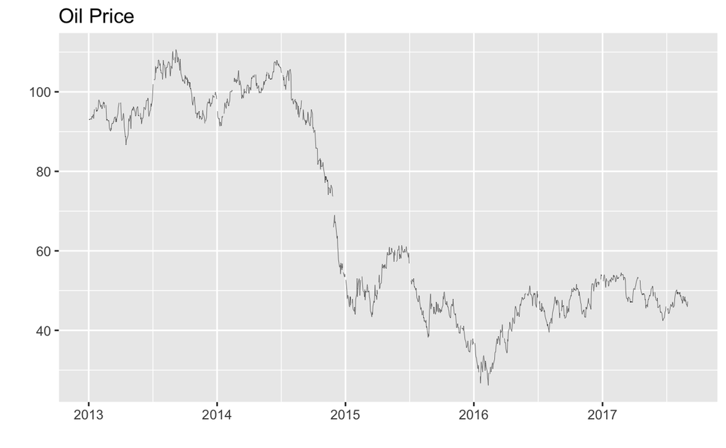

```r
ggplot(oil)+geom_line(aes(x=Date, y=dcoilwtico), size=0.1)+
  labs(title="Oil Price", x="", y="")
```

### items

Now, let us explore the items metadata.

```r
items <- fread('items.csv', showProgress = TRUE)
```

```r
items[, lapply(.SD, function(x) length(unique(x)))]
glimpse(items)
```

```r
items$Item_nbr <- as.factor(items$item_nbr)
items$Family <- as.factor(items$family)
items$Class <- as.factor(items$class)
items$Perishable <- as.factor(items$perishable)
items$weight <- ifelse(items$perishable==1, 1.25, 1)
```

```r
describe(items)
```

There were 4,100 items from 33 product families, ranging from seafood, school and office supplies to baby care and automotive items in 337 product classes. Around 24% of all items are perishable. An additional weight variable is created for the metric calculation of model evaluation.

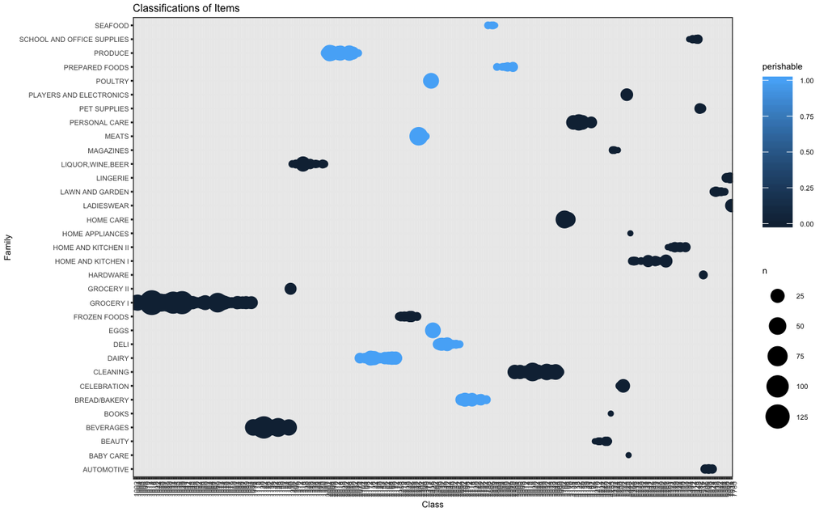

```r
ggplot(items)+geom_count(aes(x=Class, y=Family, color=perishable)) +
  theme_bw(base_size = 5) +
  theme(axis.text.x=element_text(angle=90,hjust=1))+
  labs(title="Classifications of Items")
```

Within an item family, item class numbers are grouped in ascending order. As the name of the competition suggested, Favorita sold most items in Grocery I, followed by Beverages & Cleaning items.

##### holidays_events

Now, let us take a look at the holiday and events metadata and do some variable transformation.

```r
holievt <- fread('holidays_events.csv', showProgress=TRUE)
```

```r
holievt[, lapply(.SD, function(x) length(unique(x)))]
glimpse(holievt)
describe(holievt)
```

```r
holievt$Date <- ymd(holievt$date)
holievt$Type <- as.factor(holievt$type)
holievt$Locale <- as.factor(holievt$locale)
holievt$Locale_name <- as.factor(holievt$locale_name)
holievt$Transferred <- as.factor(holievt$transferred)
```

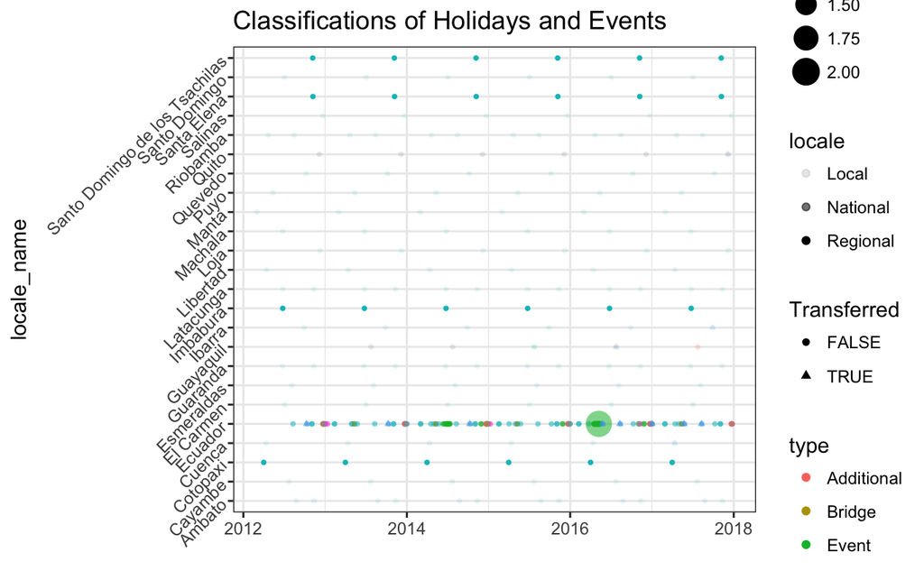

```r
ggplot(holievt)+geom_count(aes(x=Date, y=locale_name, color=type, alpha=locale, shape=Transferred))+
  theme_bw()+
  theme(axis.text.y=element_text(angle=45,hjust=1))+
  guides(fill=guide_legend(title.theme=element_text(size=6)))+
  labs(title="Classifications of Holidays and Events", x="")
```

Is the bigger circle in the first half of 2016 an especially important national holiday? Moreover, *Ecuador* seemed to be a frequent national holiday throughout the years. Let us check it out.

```r
holievt %>%
  filter(grepl("Ecuador", locale_name))
```

| date | type | locale | locale_name | description | transferred | Date | Type | Locale | Locale_name | Transferred |
| --- | --- | --- | --- | --- | --- | --- | --- | --- | --- | --- |
| 2012-08-10 | Holiday | National | Ecuador | Primer Grito de Independencia | FALSE | 2012-08-10 | Holiday | National | Ecuador | FALSE |
| 2012-10-09 | Holiday | National | Ecuador | Independencia de Guayaquil | TRUE | 2012-10-09 | Holiday | National | Ecuador | TRUE |
| 2012-10-12 | Transfer | National | Ecuador | Traslado Independencia de Guayaquil | FALSE | 2012-10-12 | Transfer | National | Ecuador | FALSE |
| 2012-11-02 | Holiday | National | Ecuador | Dia de Difuntos | FALSE | 2012-11-02 | Holiday | National | Ecuador | FALSE |
| 2012-11-03 | Holiday | National | Ecuador | Independencia de Cuenca | FALSE | 2012-11-03 | Holiday | National | Ecuador | FALSE |
| 2012-12-21 | Additional | National | Ecuador | Navidad-4 | FALSE | 2012-12-21 | Additional | National | Ecuador | FALSE |
| 2012-12-22 | Additional | National | Ecuador | Navidad-3 | FALSE | 2012-12-22 | Additional | National | Ecuador | FALSE |
| 2012-12-23 | Additional | National | Ecuador | Navidad-2 | FALSE | 2012-12-23 | Additional | National | Ecuador | FALSE |
| 2012-12-24 | Bridge | National | Ecuador | Puente Navidad | FALSE | 2012-12-24 | Bridge | National | Ecuador | FALSE |
| 2012-12-24 | Additional | National | Ecuador | Navidad-1 | FALSE | 2012-12-24 | Additional | National | Ecuador | FALSE |

[output cut: 164 more lines]

*Ecuador* represents different sorts of public holidays including Independence Day, Christmas, Easter, Battle of Pichincha, and the most important national ones: FOOTBALL championships!

```r
holievt %>%
  group_by(Date, locale_name, type, locale, Transferred) %>%
  summarise(n=n()) %>%
  arrange(-n)
```

| Date | locale_name | type | locale | Transferred | n |
| --- | --- | --- | --- | --- | --- |
| 2016-05-08 | Ecuador | Event | National | FALSE | 2 |
| 2012-03-02 | Manta | Holiday | Local | FALSE | 1 |
| 2012-04-01 | Cotopaxi | Holiday | Regional | FALSE | 1 |
| 2012-04-12 | Cuenca | Holiday | Local | FALSE | 1 |
| 2012-04-14 | Libertad | Holiday | Local | FALSE | 1 |
| 2012-04-21 | Riobamba | Holiday | Local | FALSE | 1 |
| 2012-05-12 | Puyo | Holiday | Local | FALSE | 1 |
| 2012-06-23 | Guaranda | Holiday | Local | FALSE | 1 |
| 2012-06-25 | Imbabura | Holiday | Regional | FALSE | 1 |
| 2012-06-25 | Latacunga | Holiday | Local | FALSE | 1 |

[output cut: 339 more lines]

The bigger circle was not anything especially big, instead there was more than 1 event on the same day. Besides the Mothers day on May 8, 2016, there was a *Terremoto* (earthquake) which began on April 16 and ended on May 16, 2016.

```r
holievt %>%
  filter(grepl("Terremoto", description))
```

| date | type | locale | locale_name | description | transferred | Date | Type | Locale | Locale_name | Transferred |
| --- | --- | --- | --- | --- | --- | --- | --- | --- | --- | --- |
| 2016-04-16 | Event | National | Ecuador | Terremoto Manabi | FALSE | 2016-04-16 | Event | National | Ecuador | FALSE |
| 2016-04-17 | Event | National | Ecuador | Terremoto Manabi+1 | FALSE | 2016-04-17 | Event | National | Ecuador | FALSE |
| 2016-04-18 | Event | National | Ecuador | Terremoto Manabi+2 | FALSE | 2016-04-18 | Event | National | Ecuador | FALSE |
| 2016-04-19 | Event | National | Ecuador | Terremoto Manabi+3 | FALSE | 2016-04-19 | Event | National | Ecuador | FALSE |
| 2016-04-20 | Event | National | Ecuador | Terremoto Manabi+4 | FALSE | 2016-04-20 | Event | National | Ecuador | FALSE |
| 2016-04-21 | Event | National | Ecuador | Terremoto Manabi+5 | FALSE | 2016-04-21 | Event | National | Ecuador | FALSE |
| 2016-04-22 | Event | National | Ecuador | Terremoto Manabi+6 | FALSE | 2016-04-22 | Event | National | Ecuador | FALSE |
| 2016-04-23 | Event | National | Ecuador | Terremoto Manabi+7 | FALSE | 2016-04-23 | Event | National | Ecuador | FALSE |
| 2016-04-24 | Event | National | Ecuador | Terremoto Manabi+8 | FALSE | 2016-04-24 | Event | National | Ecuador | FALSE |
| 2016-04-25 | Event | National | Ecuador | Terremoto Manabi+9 | FALSE | 2016-04-25 | Event | National | Ecuador | FALSE |

[output cut: 21 more lines]

```r
data$date_store <- str_c(data$date.x, "//", as.character(data$store_nbr))

data <- train %>%
  left_join(oil, by="Date") %>%
  left_join(stores, by="Store_nbr") %>%
  left_join(items, by="Item_nbr") %>%
  left_join(holievt, by="Date") %>%
  left_join(tran, by="date_store")

save(data, file="data_c.Rda")
```